# NYPD Shootings Data

Leandro Mercanti

2024-07-30

This project analyzes a dataset of all shooting incidents in NYC from 2006 to the end of last year. It aims to identify trends and patterns in gun violence to support public safety initiatives and inform policy decisions.

#### Library Tidyverse:

```r
library(tidyverse)
```

#### Download the dataset here:

Link here: <“https://data.cityofnewyork.us/api/views/833y-fsy8/rows.csv?accessType=DOWNLOAD/”>

#### Read the dataset into R:

```r
nypd_dataset <- read_csv("NYPD_Shooting_Incident_Data__Historic_.csv")
```

#### Look at a summary of the dataset:

```r
summary(nypd_dataset)
```

```
##   INCIDENT_KEY        OCCUR_DATE         OCCUR_TIME           BORO
##  Min.   :  9953245   Length:28562       Length:28562      Length:28562
##  1st Qu.: 65439914   Class :character   Class1:hms        Class :character
##  Median : 92711254   Mode  :character   Class2:difftime   Mode  :character
##  Mean   :127405824                      Mode  :numeric
##  3rd Qu.:203131993
##  Max.   :279758069
##
##  LOC_OF_OCCUR_DESC     PRECINCT     JURISDICTION_CODE LOC_CLASSFCTN_DESC
##  Length:28562       Min.   :  1.0   Min.   :0.0000    Length:28562
##  Class :character   1st Qu.: 44.0   1st Qu.:0.0000    Class :character
##  Mode  :character   Median : 67.0   Median :0.0000    Mode  :character
##                     Mean   : 65.5   Mean   :0.3219
##                     3rd Qu.: 81.0   3rd Qu.:0.0000
##                     Max.   :123.0   Max.   :2.0000
##                                     NA's   :2
##  LOCATION_DESC      STATISTICAL_MURDER_FLAG PERP_AGE_GROUP
##  Length:28562       Mode :logical           Length:28562
##  Class :character   FALSE:23036             Class :character
##  Mode  :character   TRUE :5526              Mode  :character
##
##
##
##
##    PERP_SEX          PERP_RACE         VIC_AGE_GROUP        VIC_SEX
##  Length:28562       Length:28562       Length:28562       Length:28562
##  Class :character   Class :character   Class :character   Class :character
##  Mode  :character   Mode  :character   Mode  :character   Mode  :character
##
##
##
##
##    VIC_RACE           X_COORD_CD        Y_COORD_CD        Latitude
##  Length:28562       Min.   : 914928   Min.   :125757   Min.   :40.51
##  Class :character   1st Qu.:1000068   1st Qu.:182912   1st Qu.:40.67
##  Mode  :character   Median :1007772   Median :194901   Median :40.70
##                     Mean   :1009424   Mean   :208380   Mean   :40.74
##                     3rd Qu.:1016807   3rd Qu.:239814   3rd Qu.:40.82
##                     Max.   :1066815   Max.   :271128   Max.   :40.91
##                                                        NA's   :59
##    Longitude        Lon_Lat
##  Min.   :-74.25   Length:28562
##  1st Qu.:-73.94   Class :character
##  Median :-73.92   Mode  :character
##  Mean   :-73.91
##  3rd Qu.:-73.88
##  Max.   :-73.70
##  NA's   :59
```

```r
glimpse(nypd_dataset)
```

```
## Rows: 28,562
## Columns: 21
## $ INCIDENT_KEY            <dbl> 244608249, 247542571, 84967535, 202853370, 270…
## $ OCCUR_DATE              <chr> "05/05/2022", "07/04/2022", "05/27/2012", "09/…
## $ OCCUR_TIME              <time> 00:10:00, 22:20:00, 19:35:00, 21:00:00, 21:00…
## $ BORO                    <chr> "MANHATTAN", "BRONX", "QUEENS", "BRONX", "BROO…
## $ LOC_OF_OCCUR_DESC       <chr> "INSIDE", "OUTSIDE", NA, NA, NA, NA, NA, NA, N…
## $ PRECINCT                <dbl> 14, 48, 103, 42, 83, 23, 113, 77, 48, 49, 73, …
## $ JURISDICTION_CODE       <dbl> 0, 0, 0, 0, 0, 2, 0, 0, 0, 0, 0, 0, 0, 0, 0, 0…
## $ LOC_CLASSFCTN_DESC      <chr> "COMMERCIAL", "STREET", NA, NA, NA, NA, NA, NA…
## $ LOCATION_DESC           <chr> "VIDEO STORE", "(null)", NA, NA, NA, "MULTI DW…
## $ STATISTICAL_MURDER_FLAG <lgl> TRUE, TRUE, FALSE, FALSE, FALSE, FALSE, TRUE, …
## $ PERP_AGE_GROUP          <chr> "25-44", "(null)", NA, "25-44", "25-44", NA, N…
## $ PERP_SEX                <chr> "M", "(null)", NA, "M", "M", NA, NA, NA, NA, "…
## $ PERP_RACE               <chr> "BLACK", "(null)", NA, "UNKNOWN", "BLACK", NA,…
## $ VIC_AGE_GROUP           <chr> "25-44", "18-24", "18-24", "25-44", "25-44", "…
## $ VIC_SEX                 <chr> "M", "M", "M", "M", "M", "M", "M", "M", "M", "…
## $ VIC_RACE                <chr> "BLACK", "BLACK", "BLACK", "BLACK", "BLACK", "…
## $ X_COORD_CD              <dbl> 986050, 1016802, 1048632, 1014493, 1009149, 99…
## $ Y_COORD_CD              <dbl> 214231.0, 250581.0, 198262.0, 242565.0, 190104…
## $ Latitude                <dbl> 40.75469, 40.85440, 40.71063, 40.83242, 40.688…
## $ Longitude               <dbl> -73.99350, -73.88233, -73.76777, -73.89071, -7…
## $ Lon_Lat                 <chr> "POINT (-73.9935 40.754692)", "POINT (-73.8823…
```

#### Cleaning up the Dataset and making the data tidy:

1. Rename columns for date and time (rename)
2. Convert DATE column to Date type (mutate)
3. Convert some columns to Factor (as.factor)
4. Remove unnecessary columns (select)

```r
nypd_dataset <- nypd_dataset %>%
  rename(DATE = OCCUR_DATE,
         TIME = OCCUR_TIME) %>%
  mutate(DATE = mdy(DATE),
         BORO = as.factor(BORO),
         STATISTICAL_MURDER_FLAG = as.factor(STATISTICAL_MURDER_FLAG),
         PERP_AGE_GROUP = as.factor(PERP_AGE_GROUP),
         PERP_SEX = as.factor(PERP_SEX),
         PERP_RACE = as.factor(PERP_RACE)) %>%
  select(-c(X_COORD_CD, Y_COORD_CD, Latitude, Longitude, Lon_Lat))
```

#### Take another look at a summary of the dataset after the cleaning:

```r
summary(nypd_dataset)
```

```
##   INCIDENT_KEY            DATE                TIME
##  Min.   :  9953245   Min.   :2006-01-01   Length:28562
##  1st Qu.: 65439914   1st Qu.:2009-09-04   Class1:hms
##  Median : 92711254   Median :2013-09-20   Class2:difftime
##  Mean   :127405824   Mean   :2014-06-07   Mode  :numeric
##  3rd Qu.:203131993   3rd Qu.:2019-09-29
##  Max.   :279758069   Max.   :2023-12-29
##
##             BORO       LOC_OF_OCCUR_DESC     PRECINCT     JURISDICTION_CODE
##  BRONX        : 8376   Length:28562       Min.   :  1.0   Min.   :0.0000
##  BROOKLYN     :11346   Class :character   1st Qu.: 44.0   1st Qu.:0.0000
##  MANHATTAN    : 3762   Mode  :character   Median : 67.0   Median :0.0000
##  QUEENS       : 4271                      Mean   : 65.5   Mean   :0.3219
##  STATEN ISLAND:  807                      3rd Qu.: 81.0   3rd Qu.:0.0000
##                                           Max.   :123.0   Max.   :2.0000
##                                                           NA's   :2
##  LOC_CLASSFCTN_DESC LOCATION_DESC      STATISTICAL_MURDER_FLAG PERP_AGE_GROUP
##  Length:28562       Length:28562       FALSE:23036             18-24  :6438
##  Class :character   Class :character   TRUE : 5526             25-44  :6041
##  Mode  :character   Mode  :character                           UNKNOWN:3148
##                                                                <18    :1682
##                                                                (null) :1141
##                                                                (Other): 768
##                                                                NA's   :9344
##    PERP_SEX              PERP_RACE     VIC_AGE_GROUP        VIC_SEX
##  (null): 1141   BLACK         :11903   Length:28562       Length:28562
##  F     :  444   WHITE HISPANIC: 2510   Class :character   Class :character
##  M     :16168   UNKNOWN       : 1837   Mode  :character   Mode  :character
##  U     : 1499   BLACK HISPANIC: 1392
##  NA's  : 9310   (null)        : 1141
##                 (Other)       :  469
##                 NA's          : 9310
##    VIC_RACE
##  Length:28562
##  Class :character
##  Mode  :character
##
##
##
##
```

```r
glimpse(nypd_dataset)
```

```
## Rows: 28,562
## Columns: 16
## $ INCIDENT_KEY            <dbl> 244608249, 247542571, 84967535, 202853370, 270…
## $ DATE                    <date> 2022-05-05, 2022-07-04, 2012-05-27, 2019-09-2…
## $ TIME                    <time> 00:10:00, 22:20:00, 19:35:00, 21:00:00, 21:00…
## $ BORO                    <fct> MANHATTAN, BRONX, QUEENS, BRONX, BROOKLYN, MAN…
## $ LOC_OF_OCCUR_DESC       <chr> "INSIDE", "OUTSIDE", NA, NA, NA, NA, NA, NA, N…
## $ PRECINCT                <dbl> 14, 48, 103, 42, 83, 23, 113, 77, 48, 49, 73, …
## $ JURISDICTION_CODE       <dbl> 0, 0, 0, 0, 0, 2, 0, 0, 0, 0, 0, 0, 0, 0, 0, 0…
## $ LOC_CLASSFCTN_DESC      <chr> "COMMERCIAL", "STREET", NA, NA, NA, NA, NA, NA…
## $ LOCATION_DESC           <chr> "VIDEO STORE", "(null)", NA, NA, NA, "MULTI DW…
## $ STATISTICAL_MURDER_FLAG <fct> TRUE, TRUE, FALSE, FALSE, FALSE, FALSE, TRUE, …
## $ PERP_AGE_GROUP          <fct> 25-44, (null), NA, 25-44, 25-44, NA, NA, NA, N…
## $ PERP_SEX                <fct> M, (null), NA, M, M, NA, NA, NA, NA, M, NA, NA…
## $ PERP_RACE               <fct> BLACK, (null), NA, UNKNOWN, BLACK, NA, NA, NA,…
## $ VIC_AGE_GROUP           <chr> "25-44", "18-24", "18-24", "25-44", "25-44", "…
## $ VIC_SEX                 <chr> "M", "M", "M", "M", "M", "M", "M", "M", "M", "…
## $ VIC_RACE                <chr> "BLACK", "BLACK", "BLACK", "BLACK", "BLACK", "…
```

#### Checking for missing data:

```r
missing_data <- sum(is.na(nypd_dataset))
missing_data
```

```
## [1] 94135
```

#### Summary of columns with missing data:

```r
colSums(is.na(nypd_dataset))
```

```
##            INCIDENT_KEY                    DATE                    TIME
##                       0                       0                       0
##                    BORO       LOC_OF_OCCUR_DESC                PRECINCT
##                       0                   25596                       0
##       JURISDICTION_CODE      LOC_CLASSFCTN_DESC           LOCATION_DESC
##                       2                   25596                   14977
## STATISTICAL_MURDER_FLAG          PERP_AGE_GROUP                PERP_SEX
##                       0                    9344                    9310
##               PERP_RACE           VIC_AGE_GROUP                 VIC_SEX
##                    9310                       0                       0
##                VIC_RACE
##                       0
```

#### Handling missing data:

Some columns have too many missing data rows to be useful for analysis and will be excluded from the dataset:

```r
nypd_dataset <- nypd_dataset %>%
  select(-c(LOC_OF_OCCUR_DESC, LOCATION_DESC, PERP_RACE, PERP_AGE_GROUP, LOC_CLASSFCTN_DESC, PERP_SEX))
```

And then, for simplicity, all rows with any NA values will be removed:

```r
nypd_dataset <- na.omit(nypd_dataset)
```

Confirming there is no longer any missing data:

```r
sum(is.na(nypd_dataset))
```

```
## [1] 0
```

#### Data Analysis of Victims per Race:

```r
nypd_per_race <- nypd_dataset %>%
  group_by(VIC_RACE) %>%
  summarize(count = n(), .groups = 'drop') %>%
  arrange(VIC_RACE)
nypd_per_race
```

```
## # A tibble: 7 × 2
##   VIC_RACE                       count
##   <chr>                          <int>
## 1 AMERICAN INDIAN/ALASKAN NATIVE    11
## 2 ASIAN / PACIFIC ISLANDER         440
## 3 BLACK                          20234
## 4 BLACK HISPANIC                  2795
## 5 UNKNOWN                           70
## 6 WHITE                            728
## 7 WHITE HISPANIC                  4282
```

#### Plot of Victims per Race:

(Filtering out races with less than 500 cases)

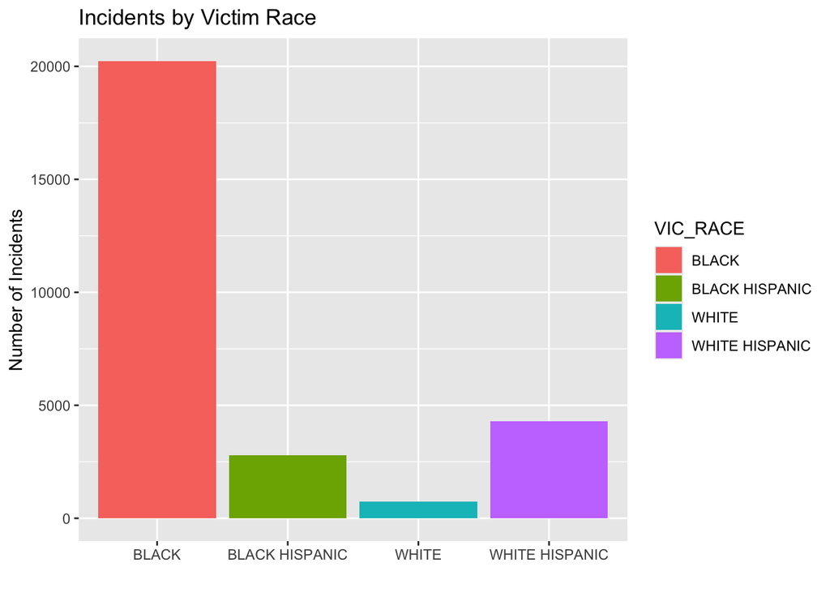

```r
nypd_per_race %>%
  filter(count > 500) %>%
  ggplot(aes(x = VIC_RACE, y = count, fill = VIC_RACE)) +
  geom_bar(stat = "identity") +
  labs(title = "Incidents by Victim Race", x = "", y = "Number of Incidents")
```

#### Data Analysis with Incidents per Boro per Year:

```r
nypd_per_boro_per_year <- nypd_dataset %>%
  mutate(YEAR = year(DATE)) %>%
  group_by(BORO, YEAR) %>%
  summarize(count = n(), .groups = 'drop') %>%
  arrange(BORO, YEAR)
nypd_per_boro_per_year
```

```
## # A tibble: 90 × 3
##    BORO   YEAR count
##    <fct> <dbl> <int>
##  1 BRONX  2006   568
##  2 BRONX  2007   533
##  3 BRONX  2008   520
##  4 BRONX  2009   529
##  5 BRONX  2010   525
##  6 BRONX  2011   571
##  7 BRONX  2012   531
##  8 BRONX  2013   371
##  9 BRONX  2014   446
## 10 BRONX  2015   409
## # ℹ 80 more rows
```

#### Plot with Incidents per Boro per Year:

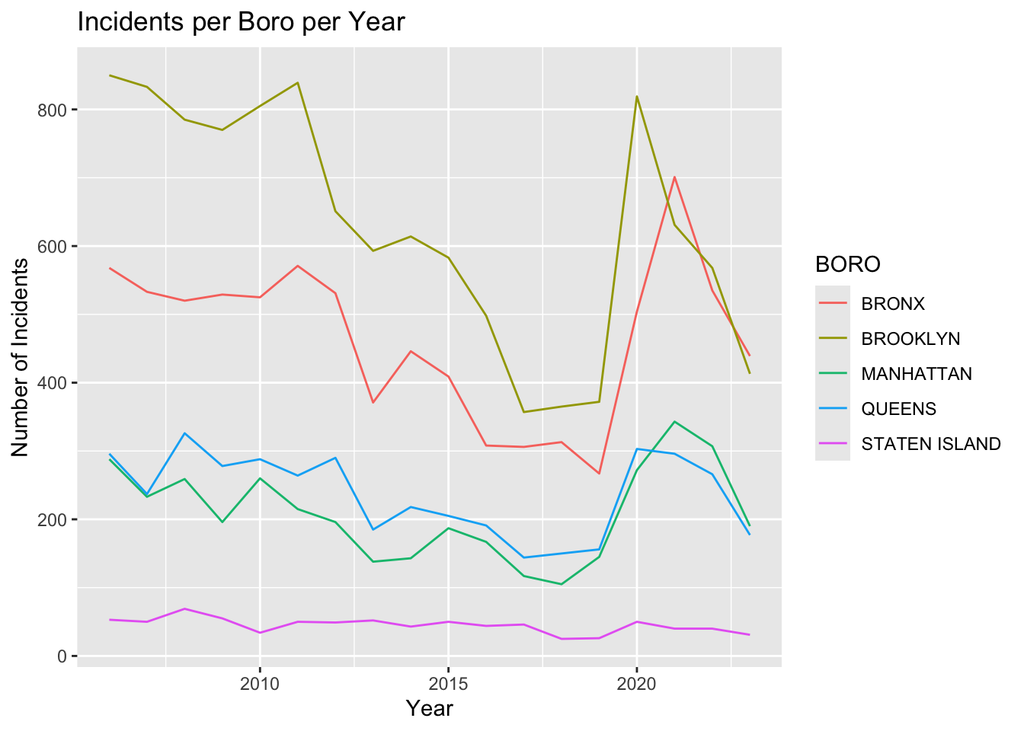

```r
nypd_per_boro_per_year %>%
  ggplot(aes(x = YEAR, y = count, color = BORO)) +
  geom_line() +
  labs(title = "Incidents per Boro per Year", x = "Year", y = "Number of Incidents")
```

#### Model with Incidents per Year:

Creating a dataset with the total number of incidents per year:

```r
nypd_per_year <- nypd_dataset %>%
  mutate(YEAR = year(DATE)) %>%
  group_by(YEAR) %>%
  summarize(total_incidents = n(), .groups = 'drop')
```

Fitting a linear model for incidents per year:

```r
lin_mod <- lm(total_incidents ~ YEAR, data = nypd_per_year)
summary(lin_mod)
```

```
##
## Call:
## lm(formula = total_incidents ~ YEAR, data = nypd_per_year)
##
## Residuals:
##     Min      1Q  Median      3Q     Max
## -529.52 -259.99   40.54  171.14  650.91
##
## Coefficients:
##             Estimate Std. Error t value Pr(>|t|)
## (Intercept) 71809.35   32426.74   2.215   0.0417 *
## YEAR          -34.86      16.10  -2.166   0.0458 *
## ---
## Signif. codes:  0 '***' 0.001 '**' 0.01 '*' 0.05 '.' 0.1 ' ' 1
##
## Residual standard error: 354.3 on 16 degrees of freedom
## Multiple R-squared:  0.2267, Adjusted R-squared:  0.1783
## F-statistic:  4.69 on 1 and 16 DF,  p-value: 0.0458
```

Plotting this linear model for incidents per year:

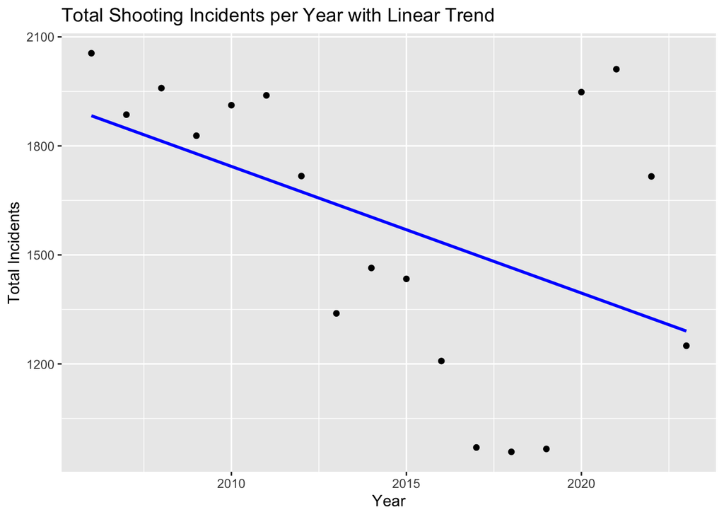

```r
nypd_per_year %>%
  ggplot(aes(x = YEAR, y = total_incidents)) +
  geom_point() +
  geom_smooth(method = "lm", se = FALSE, color = "blue") +
  labs(title = "Total Shooting Incidents per Year with Linear Trend",
       x = "Year",
       y = "Total Incidents")
```

### Conclusion

This project has provided a detailed analysis of NYPD shooting incident data from 2006 to 2023. The investigation revealed several key trends and patterns in incidents across different boroughs and victim demographics. Importantly, the data showed fluctuations in the number of incidents per borough over the years and highlighted disparities in the impact of gun violence on different racial groups.

#### Key Findings

1. **Incidents per Borough per Year:** The analysis revealed distinct trends in gun violence incidents across the five boroughs of New York City, with certain boroughs experiencing more fluctuations in the number of incidents over the years.
2. **Victims per Race:** The data indicated that certain racial groups were disproportionately affected by gun violence.

#### Potential Sources of Bias

While this analysis provides valuable insights, it is important to acknowledge potential sources of bias that could affect the findings:

1. **Selection Bias:** The dataset may not be fully representative of all shooting incidents due to potential underreporting or inconsistencies in data collection practices.
2. **Measurement Bias:** Inaccuracies in recording the date, time, and other incident details could lead to measurement bias.
3. **Exclusion of Missing Data:** My decision to exclude columns with excessive missing data and to remove rows with any NA values may have introduced bias by potentially omitting relevant information. It is important to recognize this limitation.
4. **Personal Bias:** As the author, my background and perspectives may influence the interpretation of the data.